# CFP Transfer Portal

2026-02-13

## Intro and Goal

We will be looking at the College Football Transfer Portal, it is current as of 2023.

Every year, more and more players enter the transfer portal in hopes of obtaining a starting position, earning more money, etc.

My goal is to see if we can build a model that can predict whether a a player will transfer to a Powerhouse program or not, as well as determine what factors strongly contribute to a transfer decision.

## Portal Data

This dataset shows us every player that entered the transfer portal in a particular season. It gives us their position, name, original school, destination school (if decided), and more.

```r
head(data)
```

```
##   X season first_name last_name position               origin    destination
## 1 0   2021    Cameron   Wilkins       LB             Missouri UT San Antonio
## 2 1   2021    Stephon    Wright       DL        Arizona State            SMU
## 3 2   2021      Javar    Strong        S       Arkansas State
## 4 3   2021       Noah  Mitchell       LB       UT San Antonio
## 5 4   2021 Trivenskey    Mosley       RB Southern Mississippi
## 6 5   2021      Jalar    Holley       DL                Miami
##              transfer_date rating stars eligibility
## 1 2021-07-31T14:46:00.000Z     NA     3   Immediate
## 2 2021-07-29T15:50:00.000Z     NA     4   Immediate
## 3 2021-07-28T15:25:00.000Z     NA     3   Immediate
## 4 2021-07-27T15:22:00.000Z     NA     3   Immediate
## 5 2021-07-26T00:00:00.000Z     NA     3         TBD
## 6 2021-07-25T15:28:00.000Z     NA     3   Immediate
```

## Large Number of Undecided Athletes

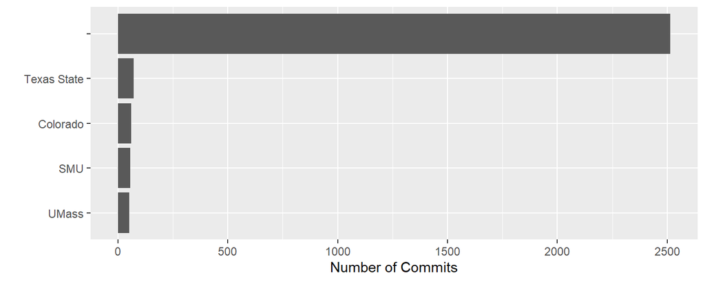

```r
top <- data %>%
  count(destination) %>%
  slice_max(n, n=5)
ggplot(top, aes(x = reorder(destination, n), y = n)) + geom_col() + coord_flip() +
  labs(x = "", y = "Number of Commits")
```

## Top 5 Schools

Here is the new dataset, with the 5 schools who received the most transfers. Texas State leads the way.

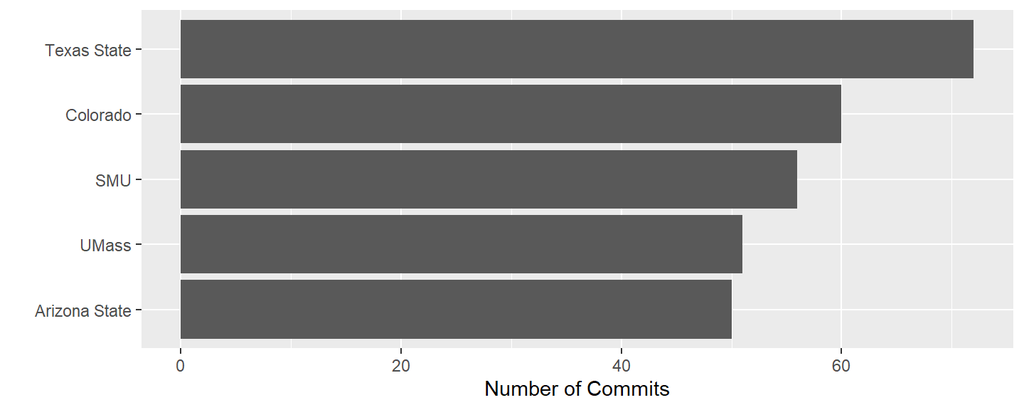

```r
top <- data %>%
  filter(!is.na(destination)) %>%
  filter(nchar(as.character(destination)) > 1) %>%
  count(destination) %>%
  slice_max(n, n=5)

ggplot(top, aes(x = reorder(destination, n), y = n,)) + geom_col() + coord_flip() + labs(x = "", y = "Number of Commits")
```

## Filter for Quality of Players

The following code filters for non-NULL values within the Top 5 schools. The average stars of transfer athletes for each school is shown in next slide.

```r
schools <- c("Texas State", "Colorado", "SMU", "UMass", "Arizona State")

topschools <- data %>%
  filter(destination %in% schools) %>%
  filter(!is.na(stars))
```

## Average stars for The Top 5 Transfer Schools

The average for each school is highlighted in Red. These schools don’t have the highest rated recruits. Texas State average 2.7 stars.

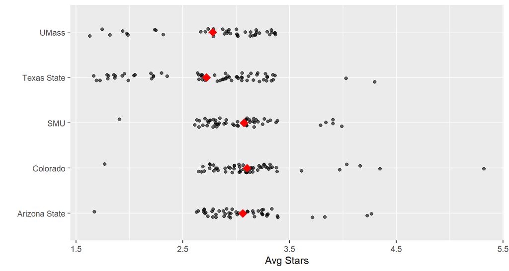

```r
ggplot(topschools, aes(x = destination, y = stars)) +
  geom_jitter(width = 0.1, alpha = 0.6) +
  stat_summary(fun = mean, geom = "point", shape = 18, size = 4, color = "red") +
  coord_flip() +
  labs(x = "", y = "Avg Stars")
```

## Who has the Highest Rated Recruits?

Now let’s look at who has the highest rated recruits, this might give us a better sample to predict.

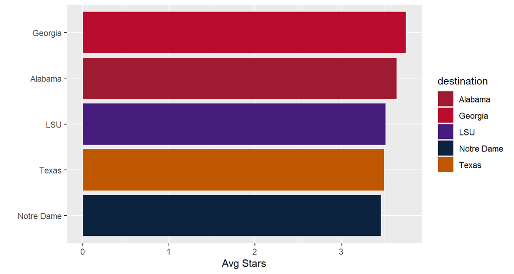

```r
toprated <- data %>%
  filter(!is.na(stars)) %>% group_by(destination) %>%
  summarise( avg_rating = mean(stars), commits= n()) %>%
  filter(commits >= 5) %>% slice_max(avg_rating, n = 10) %>%
  head(5)
ggplot(toprated, aes(x = reorder(destination, avg_rating), y = avg_rating, fill=destination))+ geom_col() + scale_fill_manual(values = team_colors) + coord_flip() + labs(x="", y="Avg Stars")
```

## Target Variable - PowerHouse Schools

Now that we know what schools have the highest rating, we can create a target variable.

```r
model_data <- data %>%
  filter(!is.na(stars) & !is.na(destination))

power_schools <- c("Alabama", "Georgia", "Ohio State", "Michigan", "Texas", "USC", "LSU", "Oklahoma", "Oregon", "Notre Dame",
"Ole Miss", "Auburn", "Florida", "Tennessee",
"Penn State", "Texas A&M")
```

## Building Model

We adjust the variables so that they can fit the logistic regression model by converting values and formatting.

```r
model_data <- model_data %>%
  mutate(
    Is_Powerhouse = ifelse(destination %in% power_schools, 1, 0),
    Origin_Type = ifelse(origin %in% power_schools, "From Power 4", "From Mid-Major"),
    Position = ifelse(position %in% c("QB","WR","RB","TE","OL","DL","LB","DB","CB","S"),
                      position, "Other")
  )
scoreModel <- glm(Is_Powerhouse ~ stars + Origin_Type + position,
                  data = model_data,
                  family = "binomial")
impact_scores <- as.data.frame(summary(scoreModel)$coefficients)
impact_scores$Variable <- rownames(impact_scores)
colnames(impact_scores)[1] <- "Impact"
```

## Setting Impact Scores

```r
impact_scores <- impact_scores %>%
  filter(Variable != "(Intercept)") %>%
  mutate(Variable = gsub("position", "", Variable)) %>%
  mutate(Variable = gsub("Origin_Type", "", Variable)) %>%
  arrange(Impact)
```

## Strongest Contributing Factors

The strongest contributing factors are stars and certain positions on the field. Punter being the greatest, due to the scarcity at the position.

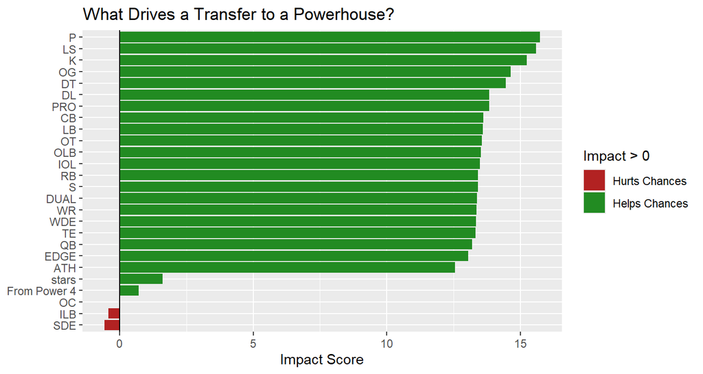

```r
ggplot(impact_scores, aes(x = reorder(Variable, Impact), y = Impact, fill = Impact > 0)) + geom_col() + coord_flip() +
  scale_fill_manual(values = c("firebrick", "forestgreen"), labels = c("Hurts Chances", "Helps Chances")) +
  geom_hline(yintercept = 0, color = "black") +
  labs(title = "What Drives a Transfer to a Powerhouse?", x = NULL, y = "Impact Score")
```

## Predicting Transfer Decision

```r
new_player <- data.frame(
  stars = 3,
  Origin_Type = "From Mid-Major",
  eligibility = "Immediate",
  position = "CB"
)
prob <- predict(scoreModel, new_player, type = "response")
print(paste("Player Profile:", new_player$stars, "Star", new_player$position,",", new_player$Origin_Type))
```

```
## [1] "Player Profile: 3 Star CB , From Mid-Major"
```

```r
print(paste("Probability of Powerhouse Destination:", round(prob * 100, 1), "%"))
```

```
## [1] "Probability of Powerhouse Destination: 4.9 %"
```

We see that a 3-star CB Recruit from a Mid-Major conference has a very low percentage of transferring to a PowerHouse School.

## Predicting - Different Inputs

```r
new_player <- data.frame(
  stars = 4,
  Origin_Type = "From Power 4",
  eligibility = "Immediate",
  position = "P"
)
prob <- predict(scoreModel, new_player, type = "response")
print(paste("Player Profile:", new_player$stars, "Star", new_player$position,",", new_player$Origin_Type))
```

```
## [1] "Player Profile: 4 Star P , From Power 4"
```

```r
print(paste("Probability of Powerhouse Destination:", round(prob * 100, 1), "%"))
```

```
## [1] "Probability of Powerhouse Destination: 81.7 %"
```

4-star Punter from Power 4 has an 81% chance they transfer to a PowerHouse School.

## Model Accuracy

Lastly we find the model accuracy:

```r
probs <- predict(scoreModel, type = "response")
predictions <- ifelse(probs > 0.5, 1, 0)
accuracy <- mean(predictions == model_data$Is_Powerhouse)
table(Predicted = predictions, Actual = model_data$Is_Powerhouse)
```

```
##          Actual
## Predicted    0    1
##         0 5608  391
##         1   13    7
```

```r
print(paste("Total Model Accuracy:", round(accuracy * 100, 1), "%"))
```

```
## [1] "Total Model Accuracy: 93.3 %"
```

## Conclusion

We found that the strongest factors that influence a transfer decision were:

-Position  
-Star Rating

Using those factors, we were able to predict the probability of a player in the portal transferring to a Power 4 Conference or not. All with a 93% accuracy score! This model could help coaching staff know who to target based on what conference they’re in and where the player’s origin is. It helps identify trade-offs. A non Power 4 school may be able to recruit higher rated players from certain positions. Depending on the factors, they may have to settle for lower stars.  
Data was taken from https://www.kaggle.com/datasets/dubradave/college-football-portal-and-recruiting-statistics?resource=download  
Author: dubradave